# Exploring the BRFSS data

Gabriele Grasso

28 November 2019

## Setup

### Load packages

```r
library(ggplot2)
library(dplyr)
library(knitr)
knitr::opts_chunk$set(warning=FALSE)
```

### Load data

```r
load("brfss2013.RData")
```

## Part 1: Data

The database used in this exploratory data analysis (EDA) exercise results from the survey conducted by the Behavioral Risk Factor Surveillance System (BRFSS) of the unhospitalized adult population of the United States of America and some of its territories. This survey concerns preventive health practices and behaviors linked to chronic diseases. Detailed information can be found on this [link](https://www.cdc.gov/brfss/). The results of this survey are generalizable to the unhospitalized adult American population because the respondents have been randomly sampled. However, it is not possible to establish a link of causality between different variables because these are not the results of an experimental study, i.e. participants are not subject to random assignment.

## Part 2: Research questions

**Research question 1:**

It is common experience that sleeping enough is essential to a good quality of life. But how much do people sleep? Are such variables as gender and general health condition correlated to the number of sleeping hours per night?

**Research question 2:**

High cholesterol levels are a risk factor for cardio-vascular disease. It is therefore important to check this level regularly in order to prevent serious problems. Is a person’s education level correlated to the awareness of the problem posed by cholesterol?

**Research question 3:**

Physical activity of any kind is often credited with improving the mood and overall physical health. Is there a correlation between the number of days in a month in which respondents reported to have performed a physical activity and the number of days in which they reported poor physical or mental health?

## Part 3: Exploratory data analysis

**Research question 1:**

As a first exploratory step, we will plot the distribution of number of sleeping hours for the male and the female population.

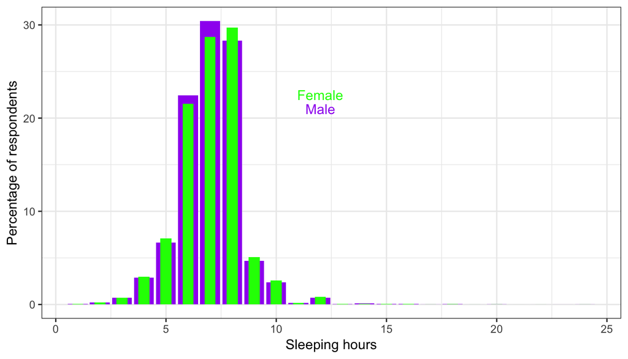

```r
male_sleeping_hours <- brfss2013 %>% filter(sex == 'Male', sleptim1 <= 24)
female_sleeping_hours <- brfss2013 %>% filter(sex == 'Female', sleptim1 <= 24)
ggplot(mapping = aes(x,y)) +
geom_bar(data = male_sleeping_hours, aes(x =sleptim1, y = (..count..)/sum(..count..)*100), fill='purple') +
geom_bar(data = female_sleeping_hours, aes(x =sleptim1, y = (..count..)/sum(..count..)*100),
width = 0.5,fill = 'green') +
xlab('Sleeping hours') + ylab('Percentage of respondents') + theme_bw() +
annotate("text", x = 12, y = 21, label = "Male", colour = 'purple') +
annotate("text", x = 12, y = 22.5, label = "Female", colour = 'green')
```

Interestingly, the two distributions are close, but the relative majority of men declares to sleep on average 7 hours per night, whereas the relative majority of women declares to sleep 8 hours. Next we will use box plots to show how the number of sleeping hours correlates to general health condition in the male population.

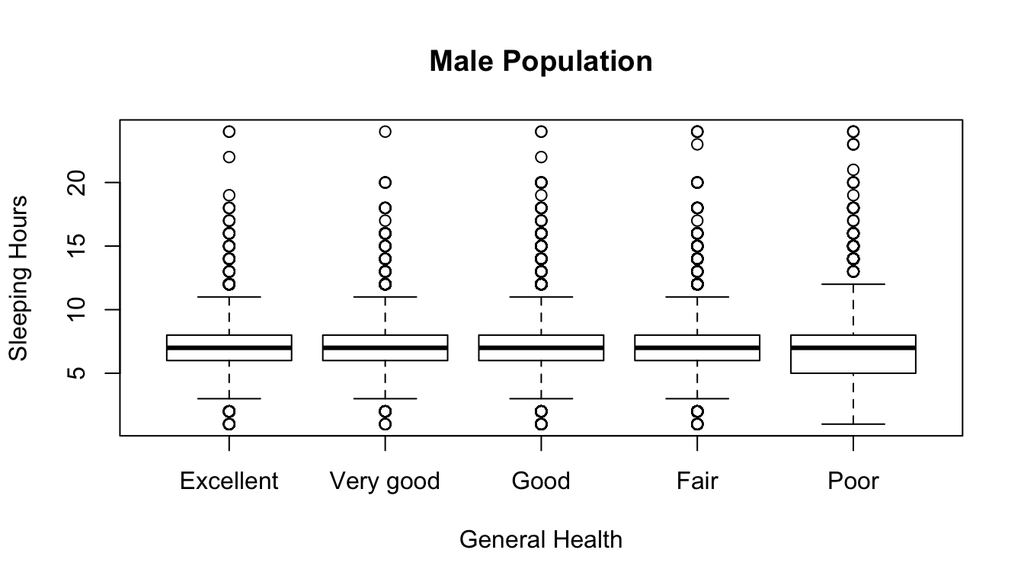

```r
boxplot(sleptim1~genhlth , data = male_sleeping_hours, xlab = "General Health",
        ylab = "Sleeping Hours", main = "Male Population")
```

As can be seen, the distributions are very similar for all health conditions from Excellent to Fair, whereas in case of Poor health the minimum and the first quartile are lower, but the maximum is higher. This suggest that Poor health is related to many different kinds of sleep trouble.

The same data visualization can be made for the female population.

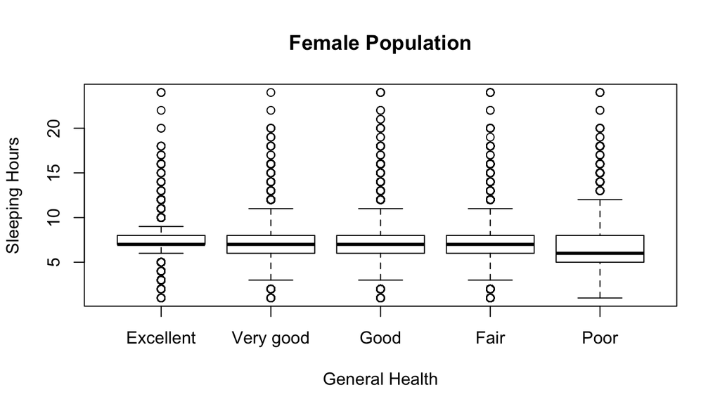

```r
boxplot(sleptim1~genhlth , data = female_sleeping_hours, xlab = "General Health",
        ylab = "Sleeping Hours", main = "Female Population")
```

In this case, women reporting Excellent health have a shorter inter-quartile range of sleeping hours than other categories, although the median is the same from Excellent to Fair health. As in the previous case, the upper and lower bounds of the distribution of sleeping hours among women who report Poor health are wider than for the other categories.

**Research question 2:**

In order to answer the second research question, we will calculate the fraction of respondents having ever had blood cholesterol checked for each education level. The results are presented in the following table.

```r
table1 <- table(brfss2013$educa, brfss2013$bloodcho)
edu_bc <- as.data.frame.matrix(prop.table(table1, margin=1))
edu_bc <- add_rownames(edu_bc, "Education")
kable(edu_bc,  caption = 'Ever Had Blood Cholesterol Checked')
```

Ever Had Blood Cholesterol Checked

| Education | Yes | No |
| --- | --- | --- |
| Never attended school or only kindergarten | 0.7324159 | 0.2675841 |
| Grades 1 through 8 (Elementary) | 0.8031919 | 0.1968081 |
| Grades 9 though 11 (Some high school) | 0.7929594 | 0.2070406 |
| Grade 12 or GED (High school graduate) | 0.8502907 | 0.1497093 |
| College 1 year to 3 years (Some college or technical school) | 0.8749696 | 0.1250304 |
| College 4 years or more (College graduate) | 0.9241134 | 0.0758866 |

It appears that at most 80% of people having lower education level (from none to some high-school) have ever had their cholesterol checked. This fraction increases to 92% for college graduates, showing a positive correlation between education level and cholesterol awareness. It is also interesting to see how check results vary with education level. The next table shows the fraction of people who were ever told that their blood cholesterol was high, for each education level.

```r
table2 <- table(brfss2013$educa, brfss2013$toldhi2)
edu_tc <- as.data.frame.matrix(prop.table(table2, margin=1))
edu_tc <- add_rownames(edu_tc, "Education")
kable(edu_tc, caption = 'Ever Told Blood Cholesterol High')
```

Ever Told Blood Cholesterol High

| Education | Yes | No |
| --- | --- | --- |
| Never attended school or only kindergarten | 0.5330490 | 0.4669510 |
| Grades 1 through 8 (Elementary) | 0.5473786 | 0.4526214 |
| Grades 9 though 11 (Some high school) | 0.5135047 | 0.4864953 |
| Grade 12 or GED (High school graduate) | 0.4711461 | 0.5288539 |
| College 1 year to 3 years (Some college or technical school) | 0.4353215 | 0.5646785 |
| College 4 years or more (College graduate) | 0.3940735 | 0.6059265 |

Slightly more than 50% of people who have none to elementary education were told that they had high cholesterol at least once in their life. This percentage descends with the level of education to 39% for college graduates. This also suggests a positive correlation between education level and cholesterol awareness.

**Research question 3:**

We will use three variables in answering the third research question. The first is a categorical variable (‘Yes’ or ‘No’) indicating if the respondents have performed any physical activity in the past 30 days or not. The other two variables represent the number of days in the past thirty in which the respondents suffered either poor physical or mental health, respectively. Preliminary statistics, reported below, show that - on average - people who have done physical activity in the previous month have also reported less days of poor physical and mental health.

```r
brfss2013 %>% filter(!is.na(exerany2)) %>% group_by(exerany2) %>%
summarise(phys_days_mean = mean(physhlth, na.rm = TRUE),
phys_days_sd = sd(physhlth, na.rm = TRUE), ment_days_mean = mean(menthlth, na.rm = TRUE),
ment_days_sd = sd(menthlth, na.rm = TRUE))
```

```
## # A tibble: 2 x 5
##   exerany2 phys_days_mean phys_days_sd ment_days_mean ment_days_sd
##   <fct>             <dbl>        <dbl>          <dbl>        <dbl>
## 1 Yes                3.23         7.48           2.84         6.91
## 2 No                 7.38        11.2            4.76         9.29
```

It is difficult, however to draw any conclusion from the previous results because the standard deviations associated to each mean value are too high. For this reason we will once again make use of box plots. The following plot concerns the distribution of days of poor physical health in the month prior to the interview.

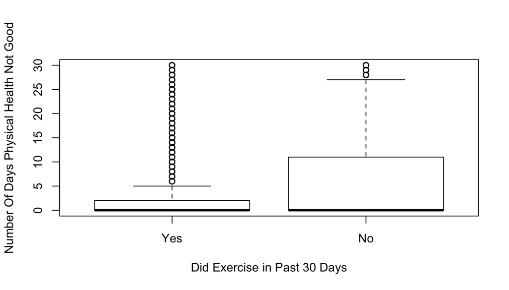

```r
boxplot(physhlth~exerany2, data = brfss2013, xlab = "Did Exercise in Past 30 Days",
        ylab = "Number Of Days Physical Health Not Good")
```

The next box plots concern the distribution of days of poor mental health depending on physical exercise.

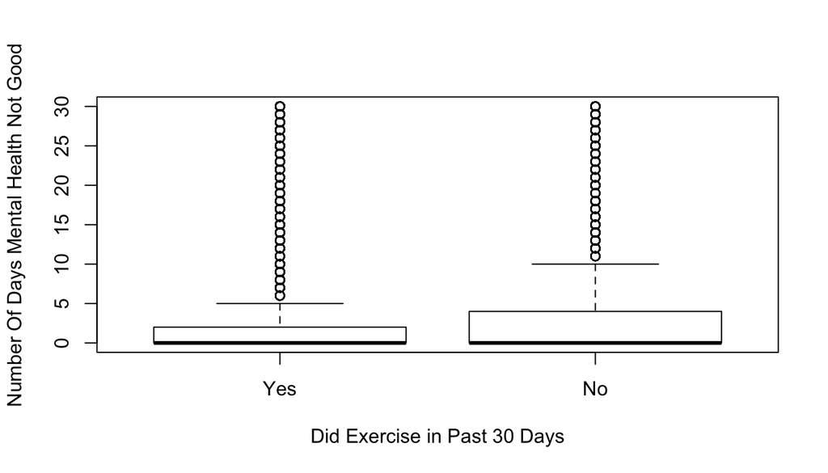

```r
boxplot(menthlth~exerany2, data = brfss2013, xlab = "Did Exercise in Past 30 Days",
        ylab = "Number Of Days Mental Health Not Good")
```